# When Your Predictor Disappears: Mediation vs. Multiple Regression

## Mediation analysis — decomposing the effect

Baron & Kenny’s framework decomposes the total effect of X → Y into:

| Path | Description |
| --- | --- |
| **c** | Total effect of X on Y (no mediator) |
| **a** | Effect of X on mediator M |
| **b** | Effect of M on Y, controlling for X |
| **c′** | Direct effect of X on Y, controlling for M |
| **a × b** | Indirect (mediated) effect |

Here: **X** = bill length · **M** = flipper length · **Y** = body mass.

```r
model_c  <- lm(body_mass_g       ~ bill_length_mm,                    data = penguins_s)  # total
model_a  <- lm(flipper_length_mm ~ bill_length_mm,                    data = penguins_s)  # path a
model_bc <- lm(body_mass_g       ~ bill_length_mm + flipper_length_mm, data = penguins_s)  # paths b & c'
```

```r
a   <- coef(model_a)["bill_length_mm"]
b   <- coef(model_bc)["flipper_length_mm"]
c   <- coef(model_c)["bill_length_mm"]
c_p <- coef(model_bc)["bill_length_mm"]

cat(sprintf(
  "  path c   (total effect, bill → body_mass):              %.3f\n
  path a   (bill_length → flipper_length):                 %.3f\n
  path b   (flipper_length → body_mass | bill_length):     %.3f\n
  path c'  (direct: bill_length → body_mass | flipper):    %.3f\n
  indirect effect a×b (mediated via flipper_length):       %.3f\n
  proportion mediated (a×b / c):                           %.1f%%\n",
  c, a, b, c_p, a * b, 100 * (a * b) / c
))
```

```
##   path c   (total effect, bill → body_mass):              0.595
##
##   path a   (bill_length → flipper_length):                 0.656
##
##   path b   (flipper_length → body_mass | bill_length):     0.844
##
##   path c'  (direct: bill_length → body_mass | flipper):    0.041
##
##   indirect effect a×b (mediated via flipper_length):       0.554
##
##   proportion mediated (a×b / c):                           93.1%
```

93% of bill length’s association with body mass is carried through flipper length. The direct path c′ is near-zero and non-significant — classic **full mediation**.

## Figure 3 — Path diagram

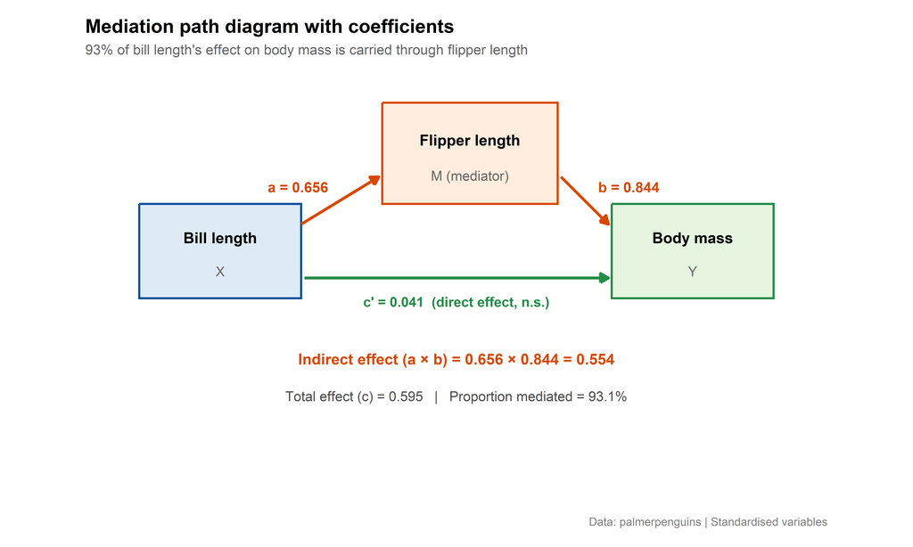

```r
a_r  <- round(a,   3)
b_r  <- round(b,   3)
c_r  <- round(c,   3)
cp_r <- round(c_p, 3)
ab_r <- round(a * b, 3)

ggplot() +
  xlim(0, 10) + ylim(0, 6) +
  coord_fixed() +

  # Boxes
  annotate("rect", xmin = 0.3, xmax = 2.7, ymin = 2.8, ymax = 4.2,
           fill = "#deebf7", color = "#08519c", linewidth = 0.8) +
  annotate("rect", xmin = 3.9, xmax = 6.5, ymin = 4.2, ymax = 5.7,
           fill = "#feedde", color = "#d94801", linewidth = 0.8) +
  annotate("rect", xmin = 7.3, xmax = 9.7, ymin = 2.8, ymax = 4.2,
           fill = "#e5f5e0", color = "#238b45", linewidth = 0.8) +

  # Labels
  annotate("text", x = 1.5, y = 3.7,  label = "Bill length",    fontface = "bold", size = 4.2) +
  annotate("text", x = 1.5, y = 3.2,  label = "X",              color = "grey40",  size = 3.8) +
  annotate("text", x = 5.2, y = 5.15, label = "Flipper length", fontface = "bold", size = 4.2) +
  annotate("text", x = 5.2, y = 4.62, label = "M (mediator)",   color = "grey40",  size = 3.8) +
  annotate("text", x = 8.5, y = 3.7,  label = "Body mass",      fontface = "bold", size = 4.2) +
  annotate("text", x = 8.5, y = 3.2,  label = "Y",              color = "grey40",  size = 3.8) +

  # Arrow a: X → M
  annotate("segment", x = 2.7, xend = 3.85, y = 3.9, yend = 4.6,
           arrow = arrow(length = unit(0.25, "cm"), type = "closed"),
           color = "#d94801", linewidth = 1.1) +
  annotate("text", x = 3.1, y = 4.45, label = paste0("a = ", a_r),
           color = "#d94801", fontface = "bold", size = 4, hjust = 1) +

  # Arrow b: M → Y
  annotate("segment", x = 6.55, xend = 7.25, y = 4.6, yend = 3.9,
           arrow = arrow(length = unit(0.25, "cm"), type = "closed"),
           color = "#d94801", linewidth = 1.1) +
  annotate("text", x = 7.1, y = 4.45, label = paste0("b = ", b_r),
           color = "#d94801", fontface = "bold", size = 4, hjust = 0) +

  # Arrow c': X → Y (direct)
  annotate("segment", x = 2.75, xend = 7.25, y = 3.1, yend = 3.1,
           arrow = arrow(length = unit(0.25, "cm"), type = "closed"),
           color = "#238b45", linewidth = 1.1) +
  annotate("text", x = 5.0, y = 2.75,
           label = paste0("c' = ", cp_r, "  (direct effect, n.s.)"),
           color = "#238b45", fontface = "bold", size = 3.8) +

  # Summary text
  annotate("text", x = 5.0, y = 1.9,
           label = paste0("Indirect effect (a \u00d7 b) = ", a_r, " \u00d7 ", b_r, " = ", ab_r),
           color = "#d94801", fontface = "bold", size = 4.2) +
  annotate("text", x = 5.0, y = 1.35,
           label = paste0("Total effect (c) = ", c_r,
                          "   |   Proportion mediated = ",
                          round(100 * (a * b) / c, 1), "%"),
           color = "grey30", size = 3.8) +

  labs(
    title    = "Mediation path diagram with coefficients",
    subtitle = "93% of bill length's effect on body mass is carried through flipper length",
    caption  = "Data: palmerpenguins | Standardised variables"
  ) +
  theme_void(base_size = 13) +
  theme(
    plot.title      = element_text(face = "bold", size = 15, margin = margin(b = 6)),
    plot.subtitle   = element_text(color = "grey40", size = 11, margin = margin(b = 4)),
    plot.caption    = element_text(color = "grey50", size = 9,  margin = margin(t = 8)),
    plot.background = element_rect(fill = "white", color = NA),
    plot.margin     = margin(15, 15, 15, 15)
  )
```

## Bootstrap significance test

The {mediation} package tests the indirect effect (a × b) via bootstrapping — no distributional assumptions required.

```r
set.seed(42)
med_out <- mediate(
  model.m  = model_a,
  model.y  = model_bc,
  treat    = "bill_length_mm",
  mediator = "flipper_length_mm",
  boot     = TRUE,
  sims     = 1000
)
summary(med_out)
```

```
##
## Causal Mediation Analysis
##
## Nonparametric Bootstrap Confidence Intervals with the Percentile Method
##
##                 Estimate 95% CI Lower 95% CI Upper p-value
## ACME            0.553939     0.472349     0.637712  <2e-16 ***
## ADE             0.041170    -0.023057     0.104997   0.214
## Total Effect    0.595110     0.508056     0.692992  <2e-16 ***
## Prop. Mediated  0.930819     0.832400     1.040169  <2e-16 ***
## ---
## Signif. codes:  0 '***' 0.001 '**' 0.01 '*' 0.05 '.' 0.1 ' ' 1
##
## Sample Size Used: 342
##
##
## Simulations: 1000
```

> **ACME** (Average Causal Mediation Effect) = the indirect effect (a × b): how much of bill length’s effect on body mass travels *through* flipper length.  
> **ADE** (Average Direct Effect) = the direct effect (c′).  
> **Total Effect** = ACME + ADE = path c.

The bootstrap 95% CI for ACME excludes zero, confirming that the mediated path is statistically reliable.

## Figure 4 — Partial regression plots

Partial regression plots make the story visual. Each plot shows what’s left of a predictor — and of body mass — *after* removing the other predictor’s linear influence.

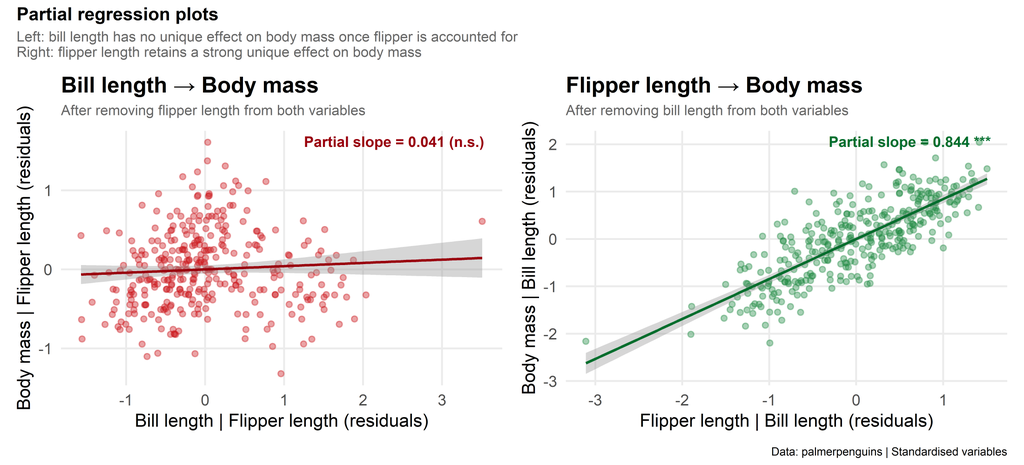

```r
# Residualise bill and body mass after removing flipper's effect
resid_bill_on_flipper <- residuals(lm(bill_length_mm   ~ flipper_length_mm, data = penguins_s))
resid_body_on_flipper <- residuals(lm(body_mass_g      ~ flipper_length_mm, data = penguins_s))

# Residualise flipper and body mass after removing bill's effect
resid_flip_on_bill    <- residuals(lm(flipper_length_mm ~ bill_length_mm, data = penguins_s))
resid_body_on_bill    <- residuals(lm(body_mass_g       ~ bill_length_mm, data = penguins_s))

partial_df <- tibble(
  resid_bill = resid_bill_on_flipper,
  resid_flip = resid_flip_on_bill,
  resid_bm_1 = resid_body_on_flipper,
  resid_bm_2 = resid_body_on_bill
)

slope_bill <- round(coef(lm(resid_bm_1 ~ resid_bill, data = partial_df))["resid_bill"], 3)
slope_flip <- round(coef(lm(resid_bm_2 ~ resid_flip, data = partial_df))["resid_flip"], 3)

p_bill <- ggplot(partial_df, aes(x = resid_bill, y = resid_bm_1)) +
  geom_point(alpha = 0.4, color = "#cb181d", size = 1.8) +
  geom_smooth(method = "lm", se = TRUE, color = "#99000d", linewidth = 0.9) +
  annotate("text", x = Inf, y = Inf, hjust = 1.1, vjust = 1.5,
           label = paste0("Partial slope = ", slope_bill, " (n.s.)"),
           color = "#99000d", fontface = "bold", size = 4) +
  labs(
    x        = "Bill length | Flipper length (residuals)",
    y        = "Body mass | Flipper length (residuals)",
    title    = "Bill length \u2192 Body mass",
    subtitle = "After removing flipper length from both variables"
  ) +
  theme_blog

p_flip <- ggplot(partial_df, aes(x = resid_flip, y = resid_bm_2)) +
  geom_point(alpha = 0.4, color = "#238b45", size = 1.8) +
  geom_smooth(method = "lm", se = TRUE, color = "#006d2c", linewidth = 0.9) +
  annotate("text", x = Inf, y = Inf, hjust = 1.1, vjust = 1.5,
           label = paste0("Partial slope = ", slope_flip, " ***"),
           color = "#006d2c", fontface = "bold", size = 4) +
  labs(
    x        = "Flipper length | Bill length (residuals)",
    y        = "Body mass | Bill length (residuals)",
    title    = "Flipper length \u2192 Body mass",
    subtitle = "After removing bill length from both variables"
  ) +
  theme_blog

p_bill + p_flip +
  plot_annotation(
    title    = "Partial regression plots",
    subtitle = "Left: bill length has no unique effect on body mass once flipper is accounted for\nRight: flipper length retains a strong unique effect on body mass",
    caption  = "Data: palmerpenguins | Standardised variables",
    theme    = theme(
      plot.title      = element_text(face = "bold", size = 14),
      plot.subtitle   = element_text(color = "grey40", size = 11),
      plot.background = element_rect(fill = "white", color = NA)
    )
  )
```

The left panel is essentially a scatter of noise — confirming that bill length has no *unique* variance to offer once flipper length has been accounted for. The right panel shows a strong, tight relationship — flipper length is doing the real work.

## Summary

|  | Simple regression | Multiple regression | Mediation |
| --- | --- | --- | --- |
| **Bill length β** | 0.595 ✓ | 0.041 ✗ | c′ = 0.041 (direct, n.s.) |
| **Flipper length β** | — | 0.844 ✓ | b = 0.844 |
| **Indirect effect** | — | — | a × b = 0.554 ✓ |
| **Proportion mediated** | — | — | 93.1% |

Multiple regression tells you the coefficient collapses; mediation analysis tells you *the effect didn’t disappear — it just got rerouted*. Bill length predicts flipper length, which in turn drives body mass. The indirect path accounts for 93% of the total effect, and the bootstrap confidence interval confirms it is statistically significant.

In plain language: bigger-billed penguins tend to have longer flippers, and longer flippers predict heavier bodies. Once you know a penguin’s flipper length, knowing the bill length adds very little extra predictive value for body mass.

*Analysis by Rahul Venugopal | Data: {palmerpenguins} | All variables standardised*